# Estimation

ECON211 · Probability & Statistics

## Contents

# Point Estimation

Guessing a parameter from a sample.

## Where do we need a guess?

**Polls.** What share of voters support a candidate?

**Finance.** What is the expected return of a stock?

**Demography.** How many children does a woman have on average?

**War.** How many weapons does the enemy produce?

**Ecology.** How many fish are there in a lake?

**Our class.** What share of students have ever cheated?

## Point estimator

Definition Let $\theta$ be a population parameter. A statistic $\hat{\theta}$ used to guess or estimate $\theta$ is called an **estimator** of $\theta$.

Note Estimator is not a particular numerical guess, but a rule or a procedure of arriving at a guess from the sample. A different sample gives a different guess.

$\bar{X}$ is an estimator of $\mu$

$s^2$ is an estimator of $\sigma^2$

But you can come up with different guesses. What makes **a good guess**, and when one guess is **better** than another? We need some **criteria** to compare estimators.

## Criteria 1: Unbiased estimator

Definition If $E(\hat{\theta})=\theta$, then $\hat{\theta}$ is an **unbiased** estimator of $\theta$. That is, your guess is unbiased if it is right on average.

$\bar{X}$ is unbiased for $\mu$

$s^2$ is unbiased for $\sigma^2$

Click an example.

$\bar{X}=\frac1n\sum_{i=1}^n X_i$ is a **random variable**: a different sample gives a different $\bar{X}$. Its expected value is
$$E(\bar{X})=E\!\left[\frac1n\sum_{i=1}^n X_i\right]=\mu$$

$s^2=\frac1{n-1}\sum_{i=1}^n (X_i-\bar{X})^2$ is a **random variable**: a different sample gives a different $s^2$. Its expected value is
$$E(s^2)=E\!\left[\frac1{n-1}\sum_{i=1}^n (X_i-\bar{X})^2\right]=\sigma^2$$

If we divide by $n$ instead of $n-1$, the variance estimator becomes **biased**.

# Example: randomized response

Asking a sensitive question

## A sensitive question

Question Have you ever cheated during your studies at NU?

People may **refuse** to answer, or **lie**. We want **anonymity**, but we have **no technical way** to guarantee it.

Solution: **randomized response**. Add randomness, so that no single answer reveals the truth.

## The idea

The rule If you were born in **January, February or March**, answer **“Yes”**, whatever the truth.  
Otherwise, answer **truthfully**. Asking respondents to **flip a coin** before answering is another way to randomize.

The person who collects the answers **does not know your birth month**. So a “Yes” may be forced by the rule: it does **not** reveal that you cheated.

Each respondent keeps **some anonymity**. But the answers are now a mix of forced and true ones.

## How do we estimate the truth?

We observe only the **share of “Yes” answers**.

Parameter $p=$ the true share of students who **cheated**.

How do we recover $p$ from the data, when some of the “Yes” answers are not true?

## Our class survey

Question: **Have you ever cheated during your studies at NU?** Rule: born in January, February or March, answer “Yes”; otherwise truthfully.

“No” 60%

“Yes” 40%

What is your guess for $p$, the true share of students who cheated? Is it 40%, more, or less?

## Working out the estimator

About $\tfrac{3}{12}=\tfrac14$ of people are forced to say “Yes”; the other $\tfrac34$ answer truthfully:
$$P(\text{Yes})=\tfrac14\cdot 1+\tfrac34\cdot p$$

Solve for $p$ and replace $P(\text{Yes})$ by the observed share $\hat{y}$:
$$\hat{p}=\frac{\hat{y}-\frac14}{\frac34}$$

Unbiased $E(\hat{y})=P(\text{Yes})$, so $E(\hat{p})=p$

Our data $\hat{p}=\dfrac{0.40-0.25}{0.75}=0.20$

About 20% cheated. The price of privacy: the standard error is $\approx7.4$ points, against $\approx4.5$ if we could ask directly.

# Example: German tanks

World War II

## Estimating tank production

The Allies wanted to estimate German tank production $a$ from the **serial numbers** $X_i$ of captured tanks.

Allied intelligence used traditional methods (spies). Statisticians analyzed serial numbers.

| Date | Intelligence | Statisticians | Actual |
| --- | --- | --- | --- |
| June 1941 | 1,550 | 244 | **271** |
| August 1942 | 1,550 | 327 | **342** |

## A simple model

Serial numbers of captured tanks are uniform: $X_i\sim U[0,a]$. We want to estimate the maximum $a$, which is the total number of tanks.

One tank, $n=1$ Since $E[X_1]=\frac{a}{2}$, the guess $\hat{\theta}=X_1$ is **biased**.

Fix: $\hat{\theta}_{1}=2X_1$. Then $E[2X_1]=2\cdot\frac{a}{2}=a$: **unbiased**.

## Many tanks

With $n>1$ tanks we can use the sample mean: $\hat{\theta}_{\text{mean}}=2\bar{X}$.

$E[2\bar{X}]=2E[\bar{X}]=2\cdot\frac{a}{2}=a$: also **unbiased**.

Two unbiased estimators: $2X_1$ and $2\bar{X}$. **Which one is better?**

## Which is better?

We say “better” means smaller **variance**.

One observation
$$\operatorname{Var}(2X_1)=4\cdot\frac{a^2}{12}=\frac{a^2}{3}$$

Sample mean
$$\operatorname{Var}(2\bar{X})=4\cdot\frac{a^2/12}{n}=\frac{a^2}{3n}$$

$\operatorname{Var}(2\bar{X})=\frac{1}{n}\operatorname{Var}(2X_1)$: using all the data is **$n$ times more efficient**.

## Criteria 2: Efficiency

Definition Among unbiased estimators, the one with the **smaller variance** is more **efficient**.

Intuition (click) Variance is the expected **squared error** of a guess. Both estimators are right on average, but the one with lower variance is much more likely to be close to the truth in a single sample.

For an unbiased estimator $E(\hat{\theta})=\theta$, so
$$\operatorname{Var}(\hat{\theta})=E\big[(\hat{\theta}-E(\hat{\theta}))^2\big]=E\big[(\hat{\theta}-\theta)^2\big]$$
This is the **expected squared mistake** of the guess. To make this mistake as small as possible, we want the **smallest variance**.

## Simulating the tank problem

Sample size $n$:

## Better still

$$\hat{\theta}_{\max}=\frac{n+1}{n}\cdot\max(X_i)$$

Which estimator is best depends on the assumed population distribution.

## Criteria 3: Consistency

Definition An estimator is **consistent** if it converges to the true parameter as $n\to\infty$.

For this, both the **bias** and the **variance** must shrink to zero as $n\to\infty$.

## Consistency: remarks

Biased but consistent The error in small samples disappears with more data. Examples: the variance estimator that divides by $n$; $\max(X_i)$ for the upper bound $a$ of a Uniform, since $E[\max]=\frac{n}{n+1}a<a$, but the bias $-\frac{a}{n+1}$ and the variance both go to $0$.

Unbiased but inconsistent Centered on the truth, but the uncertainty never shrinks. Example: using only $X_1$ to estimate $a$.

Consistency is the “large sample minimum”: we often tolerate small-sample bias if we reach the truth with enough data.

## Three properties

| Property | Focus | Purpose |
| --- | --- | --- |
| **Unbiasedness** | Accuracy | On target **on average** |
| **Consistency** | Reliability | Error disappears as $n\to\infty$ |
| **Efficiency** | Precision | **Smallest error** among competitors |

An ideal estimator is **unbiased, consistent and efficient**. Among unbiased and consistent estimators we pick the most efficient: narrower confidence intervals, more powerful tests.

## Properties depend on the population

Remark To **establish** these properties we need **assumptions about the population distribution**. The same estimator may have a property under one model and lose it under another.

Needs a specific model $2X_1$ and $2\bar{X}$ are unbiased for $a$ **assuming** $X_i\sim U[0,a]$. If the population were Normal, $E[2\bar{X}]=2\mu\mathrel{\rlap{\,/}{=}}a$.  
Efficiency: $2\bar{X}$ is beaten by $\frac{n+1}{n}\max(X_i)$ for Uniform, but $\bar{X}$ is the most efficient for Normal.

Holds for (almost) any population $E[\bar{X}]=\mu$ and $E[s^2]=\sigma^2$: unbiased whenever the mean (variance) exists and the sample is i.i.d.  
$\bar{X}\to\mu$ as $n\to\infty$: consistent for any population with a finite mean (Law of Large Numbers).

Always ask: **under what assumption** is this property true?

## The sample mean for $\mu$

In many problems the parameter we want is a mean $\mu$, so we use $\bar{X}$.

**Polls.** The share of supporters is the mean of the 0/1 answers: $\hat{p}=\bar{X}$.

**Finance.** The expected return $\mu$ of a stock is estimated by the average of past returns.

**Medicine.** The mean drop in blood pressure is estimated by the average over the patients.

Other estimators are needed **Ecology.** How many fish are there in a lake?  
**Demography.** How many children does a woman have on average?  
**War.** How many weapons does the enemy produce?  
**Our class.** What share of students have ever cheated?

# Interval Estimation

From a guess to a range of plausible values.

## From point to interval

Main question What can we infer about $\mu$ from a simple random sample?

Our guess $\bar{X}$ is **unbiased** (on average it equals $\mu$) and **consistent** (it becomes more precise as $n$ grows).

## Consistency of the sample mean

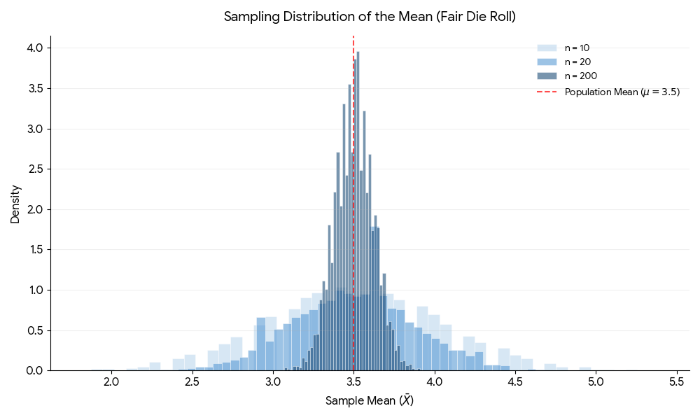

Fair die: the distribution of $\bar{X}$ narrows around $\mu=3.5$ as $n$ grows.

## Same estimator, different precision

For $n=10$, $20$ and $200$ we use the **same estimator** $\bar{X}$, and it is centred at $\mu$ every time.

But with $n=200$ the guess is **much more precise**: its variance is lower, as we saw before.

A single number does not tell us **how precise** the guess is. We need a way to **communicate the uncertainty** of our guess.

One way is to report also a variance or standard error along with the estimator, but we can do even better with an **interval estimate**.

## Confidence intervals in research

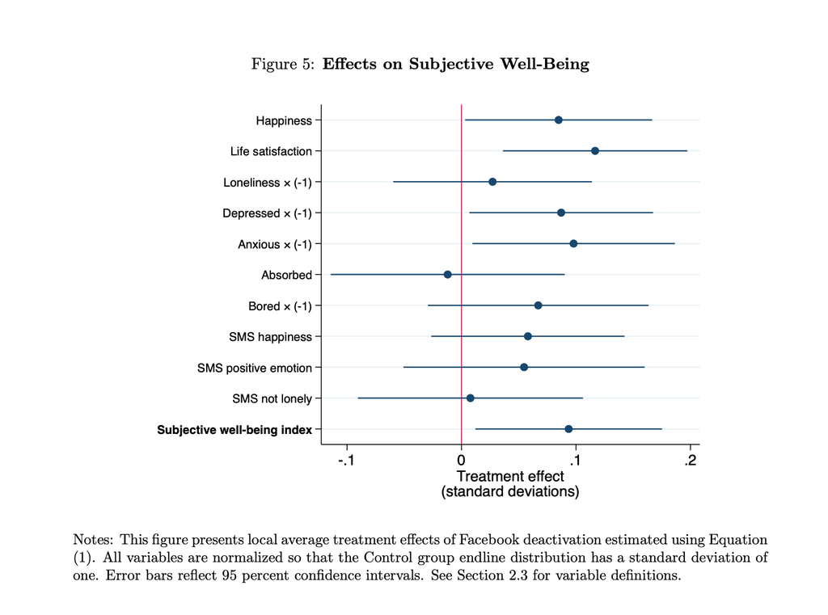

Allcott et al. (2020): effect of deactivating Facebook for one month on well-being.

## How to read the figure

The zero line The baseline: the **control group**, who kept using Facebook as usual.

The dots: point estimates The average change for the **treatment group** (those who quit). To the right of zero: they felt better.

The bars: confidence intervals Our uncertainty. If the bar does not cross zero, the effect is “statistically significant” at the 95% level. If it crosses zero, we cannot tell a real change from noise.

## Interval estimate

Idea An **interval estimate** (confidence interval) is a range of values, computed from the sample, that are **reasonable guesses** for an unknown parameter.

Here we consider interval estimates of the **population mean $\mu$** only.

Assumption The population standard deviation $\sigma$ is **known**: the only uncertainty is about $\bar{X}$. Later we drop this.

## Example: student heights

We have a sample of student heights: sample size $n=20$ and sample average $\bar{X}=170$ cm. Assume the population standard deviation is known: $\sigma=8$ cm.

Task Find a **range of reasonable guesses** for the population average $\mu$, given the information in our sample.

## The logic

Idea Take **each potential value** of the population mean $\mu$ and ask: Is the $\bar{X}$ we see in our sample **very surprising** or **not very surprising**, if this were the true $\mu$?

To answer, we need the **probability distribution of $\bar{X}$ given $\mu$**: if $\mu$ were the true mean, how would the sample mean of $20$ observations be distributed?

## The distribution of $\bar{X}$ given $\mu$

Central Limit Theorem
$$\bar{X}\sim N\!\left(\mu,\frac{\sigma^2}{n}\right)\ \text{approximately}$$

Remember that $\sigma$ is **known**, so it is a fixed number. For a given $\mu$, we know exactly how $\bar{X}$ is distributed. Now we can ask how surprising our $\bar{X}$ is.

## Measuring surprise

What is $P(\bar{X}=170)$? It is **zero**: $\bar{X}$ is (approximately) continuous, and every single point has probability zero. This question is not productive.

A better question What is the probability of a sample whose average is **as far from $\mu$ as ours**? Let $d=|\bar{X}-\mu|$ be the distance between our sample average and $\mu$:
$$P(\bar{X}\le\mu-d\ \text{ or }\ \bar{X}\ge\mu+d)=1-P(\mu-d\le\bar{X}\le\mu+d)$$

## Very surprising or not?

The probability above measures **how surprising** our sample is, given $\mu$. What counts as “very surprising”? This is a **subjective choice**, with a conventional answer: a threshold $\alpha$, called the **significance level**.

Probability $<\alpha$ Very surprising. The hypothesized $\mu$ is **unreasonable** given our sample.

Probability $>\alpha$ Not very surprising. The hypothesized $\mu$ is a **reasonable** guess.

Conventionally $\alpha$ is $10\%$, $5\%$ or $1\%$, but this is just a convention.

## Which values of $\mu$ are reasonable?

We can apply this test to **every possible value** of $\mu$. Where do the reasonable values lie, given our $\bar{X}$?

Key fact Because $\sigma$ is fixed, the **shape** of the distribution of $\bar{X}$ is the same for every $\mu$: it only **shifts** along the axis.

So for our criterion $\alpha$, the surprising values of $\bar{X}$ lie at the **same distance** $m$ from $\mu$, on both sides, whatever $\mu$ is.

## The distance $m$

We need $m$ such that
$$P(\mu-m\le\bar{X}\le\mu+m)=1-\alpha$$

$\bar{X}$ within distance $m$ of $\mu$ is **not very surprising**. Outside, it is very surprising.

## Z-scores: distance in standard deviations

Raw units depend on the problem (cm, kg, hours). To compare values, or to use **one table for every normal distribution**, we measure how far a value is from the mean **in standard deviations**:
$$z=\frac{x-\mu}{\sigma}$$

Example Heights of girls: $\mu=167$, $\sigma=8.7$ cm. A girl of $x=180$ cm has
$$z=\frac{180-167}{8.7}\approx1.49$$
She is about **1.5 standard deviations above** the mean. $z<0$ means below the mean.

## Standardizing a normal variable

Step 1: center Subtract the mean: $X-\mu$. The center moves to $0$.

Step 2: rescale Divide by the SD: $\dfrac{X-\mu}{\sigma}$. The spread becomes $1$.

Key fact If $X\sim N(\mu,\sigma^2)$, then $Z=\dfrac{X-\mu}{\sigma}\sim N(0,1)$. Hence
$$P(X\le x)=P\!\left(Z\le\tfrac{x-\mu}{\sigma}\right)=\Phi(z)$$
Every normal probability reduces to the **standard normal** table.

## Standardization: try it

$\mu$: **167.0** $\sigma$: **8.7** $x$: **180.0**

## Standardizing our probability

$\bar{X}$ has mean $\mu$ and standard deviation $\sigma/\sqrt n$ (the **standard error**), so $Z=\dfrac{\bar{X}-\mu}{\sigma/\sqrt n}\sim N(0,1)$.

Recall: we want $m$ with $P(\mu-m\le\bar{X}\le\mu+m)=1-\alpha$. Subtract $\mu$ and divide by $\sigma/\sqrt n$ inside the brackets:

$$P\!\left(-\frac{m}{\sigma/\sqrt n}\le Z\le\frac{m}{\sigma/\sqrt n}\right)=1-\alpha$$

So we look for a **constant** $c$ with $P(-c\le Z\le c)=1-\alpha$. This is a question about the standard normal only, and the standard normal table answers it.

## The critical value $z_{\alpha/2}$

Definition $z_{\alpha/2}$ is the constant with $P(-z_{\alpha/2}\le Z\le z_{\alpha/2})=1-\alpha$. There is probability $\alpha/2$ in each tail.

| Confidence level $1-\alpha$ | $\alpha$ | Tail area $\alpha/2$ | $z_{\alpha/2}$ |
| --- | --- | --- | --- |
| 90% | 0.10 | 0.05 | **1.645** |
| 95% | 0.05 | 0.025 | **1.960** |
| 99% | 0.01 | 0.005 | **2.576** |

Practice Use the standard normal table to check these values. For 95%, look for the area $0.975$ in the table and read off $1.96$.

## Solving for $m$

We set $c=z_{\alpha/2}$, so $\dfrac{m}{\sigma/\sqrt n}=z_{\alpha/2}$. Therefore
$$m=z_{\alpha/2}\,\frac{\sigma}{\sqrt n}$$
This distance $m$ is called the **margin of error**.

Our example, 95% $SE=\dfrac{8}{\sqrt{20}}\approx1.789$, so $m=1.96\times1.789\approx3.51$ cm.

## Reasonable values of $\mu$

For a given $\mu$, our $\bar{X}$ is **not very surprising** exactly when $|\bar{X}-\mu|\le m$. Equivalently: $\mu$ is reasonable when it lies within distance $m$ of $\bar{X}$.

The smallest reasonable $\mu$: our $\bar{X}$ sits exactly at the edge of its central $95\%$ region. The same holds on the other side.

## The confidence interval

Answer The reasonable values of $\mu$ lie within $m=z_{\alpha/2}\,\sigma/\sqrt n$ of $\bar{X}$: the **$(1-\alpha)$ confidence interval**
$$CI_{1-\alpha}=\left[\bar{X}-z_{\alpha/2}\frac{\sigma}{\sqrt n},\ \bar{X}+z_{\alpha/2}\frac{\sigma}{\sqrt n}\right]$$

Critical value $z_{\alpha/2}$ Point of $N(0,1)$ with area $\alpha/2$ in each tail.

Standard error $\sigma/\sqrt n$ The standard deviation of $\bar{X}$.

Margin of error $m$ Half the width of the interval.

Our example, 95%
$$CI_{0.95}=170\pm3.51=[166.49,\ 173.51]$$

## How surprising is $\bar{X}=170$ given a specific $\mu$?

Probability of $\bar{X}$ at least this far from $\mu$ (red area):

Hypothesized $\mu$: **167.00** Significance level $\alpha$:

## Interpreting the interval

If we took many samples of $20$ students and built an interval from each, about **95%** of them would contain the true mean height $\mu$.

Plausibility $160$ cm is outside our interval $[166.49,\ 173.51]$. If the true mean were $160$, a sample mean as high as $170$ would be very unlikely, so we exclude it from the plausible values.

## Precision vs. confidence

90% interval $170\pm1.645\cdot1.789$  
$=[167.06,\ 172.94]$

95% interval $170\pm1.960\cdot1.789$  
$=[166.49,\ 173.51]$

99% interval $170\pm2.576\cdot1.789$  
$=[165.39,\ 174.61]$

More confidence needs a larger critical value, so the interval gets **wider**.

## What drives the width?

The width is set by the margin of error $ME=z_{\alpha/2}\,\dfrac{\sigma}{\sqrt n}$.

| Factor | Change | Width | Precision |
| --- | --- | --- | --- |
| Sample size $n$ | $\uparrow$ | **narrows** | **increases** |
| Confidence level | $\uparrow$ | **widens** | **decreases** |
| Population SD $\sigma$ | $\uparrow$ | **widens** | **decreases** |

## The power of $n$

$n$ is the only lever that raises **both** precision and confidence.

Since $n$ sits under a square root in the standard error, you must **quadruple $n$** to cut the interval width in half.

## Choose your interval

Your width

Exact CI width

## What the game shows

Wider Covers $\mu$ **more often** than needed, but the interval is less precise.

Narrower Falls **below the target**: too many intervals miss $\mu$.

The confidence interval $\bar{X}\pm z_{\alpha/2}\,\sigma/\sqrt n$ is the **narrowest** symmetric interval that still reaches coverage $1-\alpha$ in the long run.

Luck A single run of 240 samples is noisy. A slightly narrower interval can look fine once, and even the exact CI can land a little below target. Run again to see the coverage move around.

# Example: student weight

Two confidence intervals, and what their overlap means.

## The data

Self-reported weights (kg) of ECON211 students over several semesters. As before, we **assume $\sigma$ is known** and take it equal to the sample SD of each group.

| Group | $n$ | $\bar{X}$ | $\sigma$ | $SE=\sigma/\sqrt n$ |
| --- | --- | --- | --- | --- |
| Men | 146 | 72.29 | 12.13 | 1.004 |
| Women | 224 | 55.16 | 7.93 | 0.530 |

Estimate a **95% confidence interval** for the mean weight of men, and one for women.

## 95% CI for men

$z_{0.025}=1.96$, $\ SE=\dfrac{12.13}{\sqrt{146}}\approx1.004$, $\ ME=1.96\times1.004\approx1.97$

$$CI_{0.95}^{\text{men}}=72.29\pm1.97=[70.32,\ 74.26]$$

Same data, but only $n=15$ $SE=\dfrac{12.13}{\sqrt{15}}\approx3.132$, $\ ME=1.96\times3.132\approx6.14$
$$CI_{0.95}^{\text{men}}=72.29\pm6.14=[66.15,\ 78.43]$$

## 95% CI for women

$z_{0.025}=1.96$, $\ SE=\dfrac{7.93}{\sqrt{224}}\approx0.530$, $\ ME=1.96\times0.530\approx1.04$

$$CI_{0.95}^{\text{women}}=55.16\pm1.04=[54.12,\ 56.20]$$

Same data, but only $n=15$ $SE=\dfrac{7.93}{\sqrt{15}}\approx2.048$, $\ ME=1.96\times2.048\approx4.01$
$$CI_{0.95}^{\text{women}}=55.16\pm4.01=[51.15,\ 59.17]$$

The women’s interval is narrower: smaller $\sigma$ and a larger $n$ give a smaller standard error.

## Comparing the two intervals

With the full samples the two intervals **do not overlap**: no value of $\mu$ is plausible for both groups at the same time.

With $n=15$ the intervals are **much wider** ($\pm6.14$ and $\pm4.01$): less data, less precision. They still do not overlap here, because the two means are about 17 kg apart.

## What does overlap mean?

No overlap Every plausible mean for men is larger than every plausible mean for women. The means are very likely **different**: a test of equal means at this confidence level would find a **significant difference**.

Overlap Some values are plausible for **both** groups. The data **cannot rule out** equal means: the difference could be just noise.

Overlap means “**inconclusive**”, not “the means are equal”. With more data the intervals shrink and may separate. (Even slightly overlapping intervals can hide a significant difference: non-overlap is a sufficient, not a necessary, sign.)

A formal answer (“is the difference real?”) comes with hypothesis testing. Intervals give the intuition.

## Assumptions

What the intervals rely on Independent draws, and an approximately normal $\bar{X}$. By the CLT this is fine here ($n=146$ and $224$), even though weights are skewed.

What they do not capture Weights are **self-reported**, and the sample is **not random** (only ECON211 students). A large $n$ shrinks sampling error but does **not** remove selection or reporting bias.

# Beyond the mean

The same logic works for other estimators.

## Intervals for other estimators

For the mean we used the distribution of $\bar{X}$ to build $\bar{X}\pm z_{\alpha/2}\,\sigma/\sqrt n$.

The same idea works for **any estimator**: use its sampling distribution to say how far from the truth it is likely to be. The interval communicates the **uncertainty** of the guess.

How to derive such intervals is **outside the scope of this course**. Let us just look at two of our examples, with **95%** intervals.

## Cheating: 95% interval

Randomized response: $n=78$, observed share of “Yes” $\hat{y}=0.40$, so $\hat{p}=\dfrac{0.40-0.25}{0.75}=0.20$.

$$CI_{0.95}=[\,5.5\%,\ 34.5\%\,]$$

Wide: the forced “Yes” answers add noise. This is the price of privacy.

## German tanks: 95% interval

Illustrative sample $n=10$ captured tanks, largest serial number $240$. Point estimate: $\dfrac{n+1}{n}\cdot240=264$.

$$CI_{0.95}=[\,241,\ 347\,]$$

Not symmetric around the estimate: the largest tank can be at most $a$, so the data say more about the lower side than the upper side.